# Relational Data Exercises from Hadley Wickham and Garrett Grolemund’s *R for Data Science*, Chapter 10

Stuart Barnum

2/3/2018

### 13.3.1 Exercises

##### 1. Add a surrogate key to *flights*.

```r
library(nycflights13)
flights %>% mutate(row_number = row_number())
```

```
## # A tibble: 336,776 x 20
##     year month   day dep_time sched_dep_time dep_delay arr_time
##    <int> <int> <int>    <int>          <int>     <dbl>    <int>
##  1  2013     1     1      517            515      2.00      830
##  2  2013     1     1      533            529      4.00      850
##  3  2013     1     1      542            540      2.00      923
##  4  2013     1     1      544            545     -1.00     1004
##  5  2013     1     1      554            600     -6.00      812
##  6  2013     1     1      554            558     -4.00      740
##  7  2013     1     1      555            600     -5.00      913
##  8  2013     1     1      557            600     -3.00      709
##  9  2013     1     1      557            600     -3.00      838
## 10  2013     1     1      558            600     -2.00      753
## # ... with 336,766 more rows, and 13 more variables: sched_arr_time <int>,
## #   arr_delay <dbl>, carrier <chr>, flight <int>, tailnum <chr>,
## #   origin <chr>, dest <chr>, air_time <dbl>, distance <dbl>, hour <dbl>,
## #   minute <dbl>, time_hour <dttm>, row_number <int>
```

##### 2. Identify the keys in the following datasets

`babynames::babynames`

```r
library(babynames)
babynames
```

```
## # A tibble: 1,858,689 x 5
##     year sex   name          n   prop
##    <dbl> <chr> <chr>     <int>  <dbl>
##  1  1880 F     Mary       7065 0.0724
##  2  1880 F     Anna       2604 0.0267
##  3  1880 F     Emma       2003 0.0205
##  4  1880 F     Elizabeth  1939 0.0199
##  5  1880 F     Minnie     1746 0.0179
##  6  1880 F     Margaret   1578 0.0162
##  7  1880 F     Ida        1472 0.0151
##  8  1880 F     Alice      1414 0.0145
##  9  1880 F     Bertha     1320 0.0135
## 10  1880 F     Sarah      1288 0.0132
## # ... with 1,858,679 more rows
```

```r
babynames %>%
  count(name, n, prop) %>%
  filter(nn > 1)
```

```
## # A tibble: 0 x 4
## # ... with 4 variables: name <chr>, n <int>, prop <dbl>, nn <int>
```

We thus see that (name, n, prop) specifies a key.

`nasaweather::atmos`

```r
library(nasaweather)
atmos
```

```
## # A tibble: 41,472 x 11
##      lat  long  year month surftemp  temp pressure ozone cloudlow cloudmid
##    <dbl> <dbl> <int> <int>    <dbl> <dbl>    <dbl> <dbl>    <dbl>    <dbl>
##  1  36.2  -114  1995     1      273   272      835   304     7.50    34.5
##  2  33.7  -114  1995     1      280   282      940   304    11.5     32.5
##  3  31.2  -114  1995     1      285   285      960   298    16.5     26.0
##  4  28.7  -114  1995     1      289   291      990   276    20.5     14.5
##  5  26.2  -114  1995     1      292   293     1000   274    26.0     10.5
##  6  23.7  -114  1995     1      294   294     1000   264    30.0      9.50
##  7  21.2  -114  1995     1      295   295     1000   258    29.5     11.0
##  8  18.7  -114  1995     1      298   297     1000   252    26.5     17.5
##  9  16.2  -114  1995     1      300   298     1000   250    27.5     18.5
## 10  13.7  -114  1995     1      300   299     1000   250    26.0     16.5
## # ... with 41,462 more rows, and 1 more variable: cloudhigh <dbl>
```

```r
atmos %>%
  count(lat, long, year, month) %>%
  filter(n > 1)
```

```
## # A tibble: 0 x 5
## # ... with 5 variables: lat <dbl>, long <dbl>, year <int>, month <int>,
## #   n <int>
```

We thus see that (lat, long, year, month) specifies a key.

`fueleconomy::vehicles`

```r
library(fueleconomy)
v <- vehicles
vehicles %>%
  count(id) %>%
  filter(n > 1)
```

```
## # A tibble: 0 x 2
## # ... with 2 variables: id <int>, n <int>
```

We thus see that the variable `id` is a key.

`ggplot2::diamonds`

```r
library(ggplot2)
diamonds
```

```
## # A tibble: 53,940 x 10
##    carat cut       color clarity depth table price     x     y     z
##    <dbl> <ord>     <ord> <ord>   <dbl> <dbl> <int> <dbl> <dbl> <dbl>
##  1 0.230 Ideal     E     SI2      61.5  55.0   326  3.95  3.98  2.43
##  2 0.210 Premium   E     SI1      59.8  61.0   326  3.89  3.84  2.31
##  3 0.230 Good      E     VS1      56.9  65.0   327  4.05  4.07  2.31
##  4 0.290 Premium   I     VS2      62.4  58.0   334  4.20  4.23  2.63
##  5 0.310 Good      J     SI2      63.3  58.0   335  4.34  4.35  2.75
##  6 0.240 Very Good J     VVS2     62.8  57.0   336  3.94  3.96  2.48
##  7 0.240 Very Good I     VVS1     62.3  57.0   336  3.95  3.98  2.47
##  8 0.260 Very Good H     SI1      61.9  55.0   337  4.07  4.11  2.53
##  9 0.220 Fair      E     VS2      65.1  61.0   337  3.87  3.78  2.49
## 10 0.230 Very Good H     VS1      59.4  61.0   338  4.00  4.05  2.39
## # ... with 53,930 more rows
```

```r
diamonds %>%
  count(x, y, z, price, depth, table, clarity, carat, color, clarity) %>%
  filter(n > 1)
```

```
## # A tibble: 149 x 10
##        x     y     z price depth table clarity carat color     n
##    <dbl> <dbl> <dbl> <int> <dbl> <dbl> <ord>   <dbl> <ord> <int>
##  1  0     0     0     2130  64.1  60.0 SI2     0.710 F         2
##  2  4.23  4.26  2.69   394  63.4  57.0 VS1     0.300 J         2
##  3  4.26  4.23  2.69   506  63.4  57.0 VS1     0.300 J         2
##  4  4.26  4.29  2.66   450  62.2  57.0 SI1     0.300 H         2
##  5  4.27  4.28  2.66   450  62.2  57.0 SI1     0.300 H         2
##  6  4.27  4.30  2.66   862  62.1  57.0 VVS1    0.300 E         2
##  7  4.28  4.31  2.67   552  62.2  58.0 SI1     0.300 D         2
##  8  4.29  4.31  2.71   526  63.0  55.0 VS2     0.300 G         2
##  9  4.29  4.31  2.73   571  63.5  56.0 SI1     0.310 D         2
## 10  4.31  4.28  2.67   709  62.2  58.0 SI1     0.300 D         2
## # ... with 139 more rows
```

In the diamonds dataset, grouping by all of the keys as above leaves 149 rows with more than one member. The dataset thus contains no key.

### 13.4.6 Exercises

##### 1. Compute the average delay by destination, then join on the airports data frame so you can show the spatial distribution of delays.

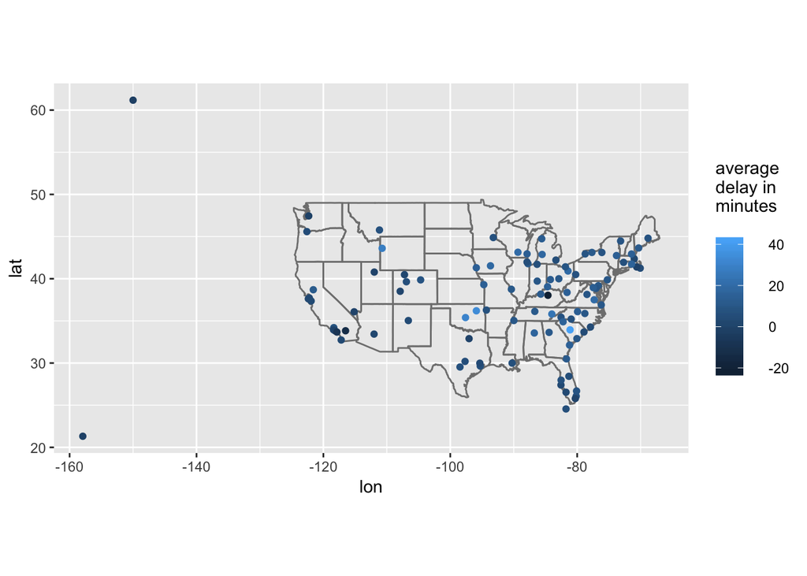

```r
ave_delay <- flights %>%
  group_by(dest) %>%
  summarize(average = mean(arr_delay, na.rm = TRUE))
airport_distribution <- ave_delay %>% left_join(airports, by = c("dest" = "faa"))

airport_distribution %>%
  filter(!is.na(lat)) %>%
  ggplot(aes(lon, lat)) +
  borders("state") +
  geom_point(aes(color = average)) +
  coord_quickmap() +
  labs(color = "average\ndelay in\nminutes")
```

###### 2. Add the location of the origin and destination (i.e. the lat and lon) to `flights`.

```r
airports_select <- airports %>% select(faa, lat, lon)

temp <- flights %>%
  left_join(airports_select, by = c("origin" = "faa")) %>%
  rename(origin_lat = lat, origin_lon = lon) %>%
  left_join(airports_select, by = c("dest" = "faa")) %>%
  rename(dest_lat = lat, dest_lon = lon)
temp
```

```
## # A tibble: 336,776 x 23
##     year month   day dep_time sched_dep_time dep_delay arr_time
##    <int> <int> <int>    <int>          <int>     <dbl>    <int>
##  1  2013     1     1      517            515      2.00      830
##  2  2013     1     1      533            529      4.00      850
##  3  2013     1     1      542            540      2.00      923
##  4  2013     1     1      544            545     -1.00     1004
##  5  2013     1     1      554            600     -6.00      812
##  6  2013     1     1      554            558     -4.00      740
##  7  2013     1     1      555            600     -5.00      913
##  8  2013     1     1      557            600     -3.00      709
##  9  2013     1     1      557            600     -3.00      838
## 10  2013     1     1      558            600     -2.00      753
## # ... with 336,766 more rows, and 16 more variables: sched_arr_time <int>,
## #   arr_delay <dbl>, carrier <chr>, flight <int>, tailnum <chr>,
## #   origin <chr>, dest <chr>, air_time <dbl>, distance <dbl>, hour <dbl>,
## #   minute <dbl>, time_hour <dttm>, origin_lat <dbl>, origin_lon <dbl>,
## #   dest_lat <dbl>, dest_lon <dbl>
```

##### 3. Is there a relationship between the age of a plane and its delays?

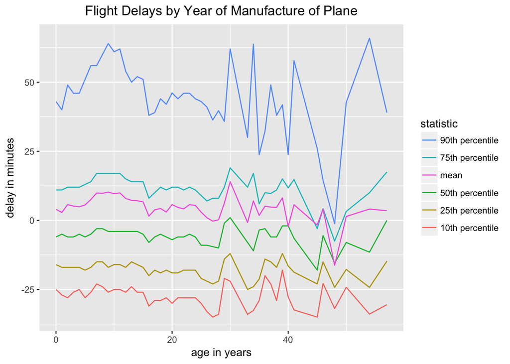

```r
#find the average arrival delay for each plane

plane_join <- flights %>%
  inner_join(planes, by = "tailnum")

delay_stats_year <- plane_join %>%
  group_by(year.y) %>%
  summarize(mean = mean(arr_delay, na.rm = TRUE),
            `50th percentile` = median(arr_delay, na.rm = TRUE),
            `25th percentile` = quantile(arr_delay, probs = .25, na.rm = TRUE),
            `75th percentile` = quantile(arr_delay, probs = .75, na.rm = TRUE),
            `10th percentile` = quantile(arr_delay, probs = .10, na.rm = TRUE),
            `90th percentile` = quantile(arr_delay, probs = .90, na.rm = TRUE))

stacked_stats <- delay_stats_year %>%
  gather(`90th percentile`, `75th percentile`, `50th percentile`, `25th percentile`,
         `10th percentile`, `mean`,
         key = "statistic", value = "value")

ggplot(stacked_stats) +
  geom_line(aes(x = 2013 - year.y, y = value,
                color = statistic)) +
  scale_color_discrete(breaks = c("90th percentile", "75th percentile", "mean",
                                  "50th percentile", "25th percentile", "10th percentile")) +
  labs(x = "age in years", y = "delay in minutes",
       title = "Flight Delays by Year of Manufacture of Plane") +
  theme(plot.title = element_text(hjust = 0.5))
```

The bump in the mean and at the upper percentiles of this plot, peaking at perhaps 8 and 9 years of age, is interesting. It appears that at least a significant number of the planes may have become less reliable over the beginning of the first decade of use, and then become more reliable (supposing, of course, that the data reflect the condition of the planes and not, say, the selection of certain models to be used in certain weather conditions).

The above data is by individual flight. Let’s look at the averages for the individual planes.

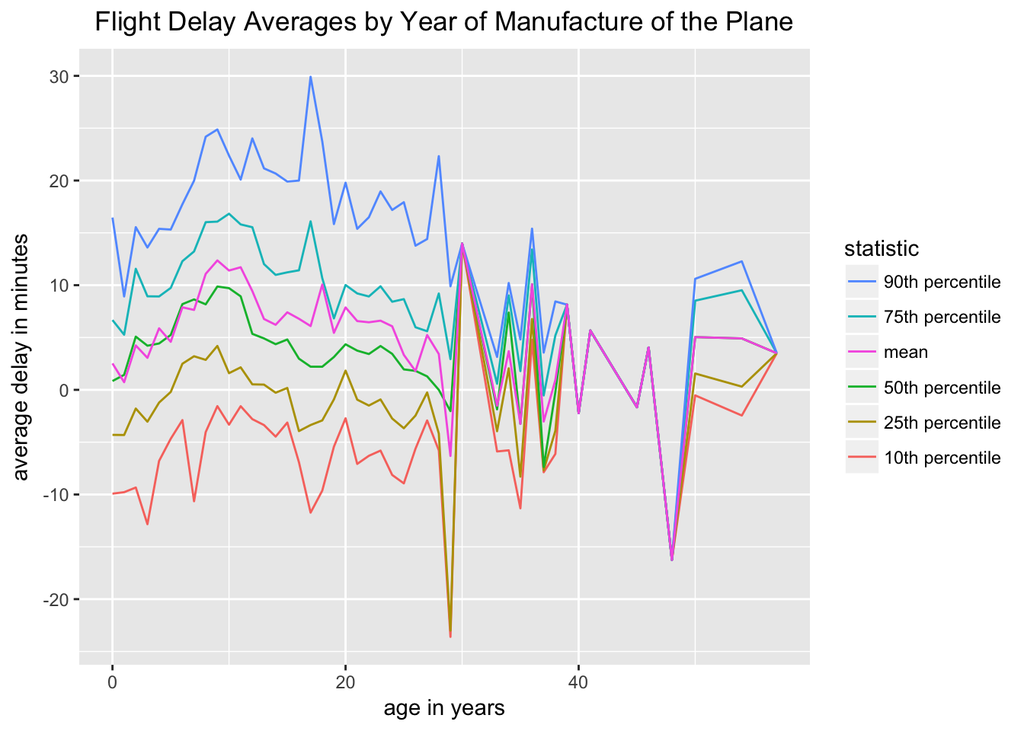

```r
plane_delay_averages <- flights %>%
  group_by(tailnum) %>%
  summarize(average_arr_delay = mean(arr_delay, na.rm = TRUE))

plane_join <- plane_delay_averages %>%
  inner_join(planes, by = "tailnum")

delay_stats_year <- plane_join %>%
  group_by(year) %>%
  summarize(mean = mean(average_arr_delay, na.rm = TRUE),
            `50th percentile` = median(average_arr_delay, na.rm = TRUE),
            `25th percentile` = quantile(average_arr_delay, probs = .25, na.rm = TRUE),
            `75th percentile` = quantile(average_arr_delay, probs = .75, na.rm = TRUE),
            `10th percentile` = quantile(average_arr_delay, probs = .10, na.rm = TRUE),
            `90th percentile` = quantile(average_arr_delay, probs = .90, na.rm = TRUE))

stacked_stats <- delay_stats_year %>%
  gather(`90th percentile`, `75th percentile`, `50th percentile`, `25th percentile`,
         `10th percentile`, `mean`,
         key = "statistic", value = "value")

ggplot(stacked_stats) +
  geom_line(aes(x = 2013 - year, y = value,
                color = statistic)) +
  scale_color_discrete(breaks = c("90th percentile", "75th percentile", "mean",
                                  "50th percentile", "25th percentile", "10th percentile")) +
  labs(x = "age in years", y = "average delay in minutes",
       title = "Flight Delay Averages by Year of Manufacture of the Plane") +
  theme(plot.title = element_text(hjust = 0.5))
```

The data for the average arrival delay for each plane is consistent with the suspicion, raised in connection with the previous plot, that, initially, the delays become somewhat greater as the planes become older, until the planes are just short of 10 years. After that, there may be a week trend towards fewer delays as the planes get older. The sudden change in the behavior of the plot after perhaps 28 years is also interesting. It might reflect a practice of taking most of the planes out of service at this relatively advanced age. Does the data contain other evidence for this hypothesis?

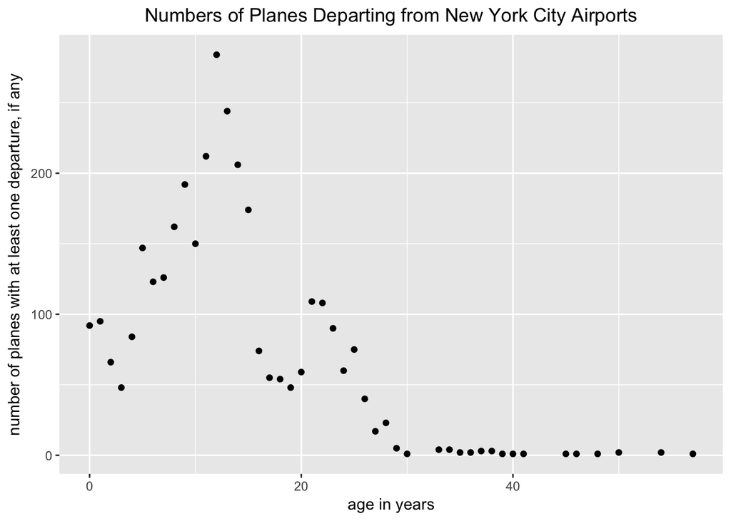

```r
older_plane_investigation <- flights %>%
  inner_join(planes, by = "tailnum") %>%
  group_by(year.y) %>%
  count(tailnum) %>%
  count(year.y)

ggplot(older_plane_investigation %>% na.omit) +
  geom_point(aes(x = 2013 - year.y, y = nn)) +
  labs(x = "age in years", y = "number of planes with at least one departure, if any",
       title = "Numbers of Planes Departing from New York City Airports") +
  theme(plot.title = element_text(hjust = 0.5))
```

As suggested in the Flight Delay Averages plot, we see from the above that the number of planes in use, for departures from New York City, falls precipitously as the planes approach 30 years in age.

##### 4. What weather conditions make it more likely to see a delay?

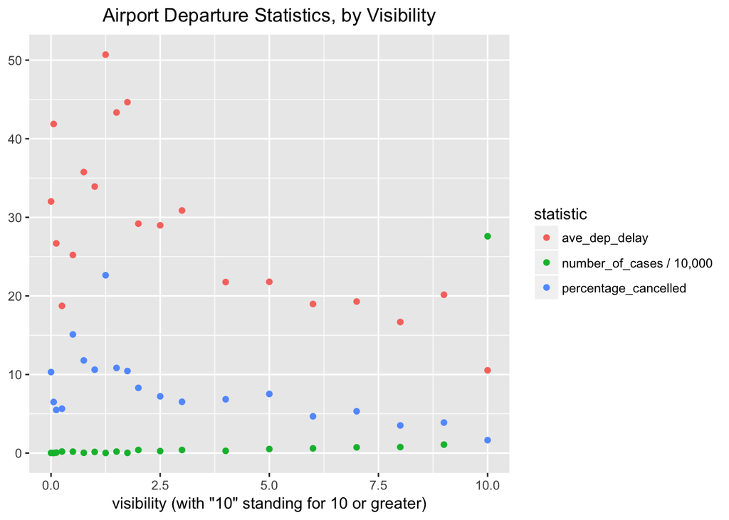

```r
#consider various averages over hours (all of the hours, in the year, reflected in the data)
weather_by_flight_by_hour <- flights %>%
  left_join(weather, by = c("year", "month", "day", "hour", "origin")) %>%
  group_by(year, month, day, hour, origin, temp, dewp, humid,
           wind_dir, wind_speed, wind_gust, precip, pressure, visib) %>%
  summarize(ave_dep_delay = mean(dep_delay, na.rm = TRUE),
            n = n(),
            proportion_cancelled = sum(is.na(dep_delay)) / n)

#To confirm some suggestions from plots of the values calculated in the above, we consider averages of delays over various values of the weather variables (or, if useful, intervals of such values)
weather_by_flight <- flights %>%
  left_join(weather, by = c("year", "month", "day", "hour", "origin")) %>%
  group_by(visib) %>%
  summarize(ave_dep_delay = mean(dep_delay, na.rm = TRUE),
            `number_of_cases / 10,000` = n() / 10000,
            percentage_cancelled = 100 * sum(is.na(dep_delay)) / n())

#put data to be plotted into a single column, to make it "tidy," and then plot it
weather_by_flight %>% na.omit() %>%
  gather(ave_dep_delay, percentage_cancelled, `number_of_cases / 10,000`,
         key = "statistic", value = "value") %>%
  ggplot() + geom_point(aes(x = visib, y = value, color = statistic)) +
  labs(x = "visibility (with \"10\" standing for 10 or greater)",
       title = "Airport Departure Statistics, by Visibility") +
  theme(plot.title = element_text(hjust = 0.5),
        axis.title.y = element_blank())
```

As visibility increases, we see a decrease in both cancellations and the delays. However, given that the vast majority of cases rest in the visibility category of 10 or greater, some guardedness in our conclusions, based on the data in the `nycflights13` package, is warranted.

##### 5. What happened on June 13 2013? Display the spatial pattern of delays, and then use Google to cross-reference with the weather.

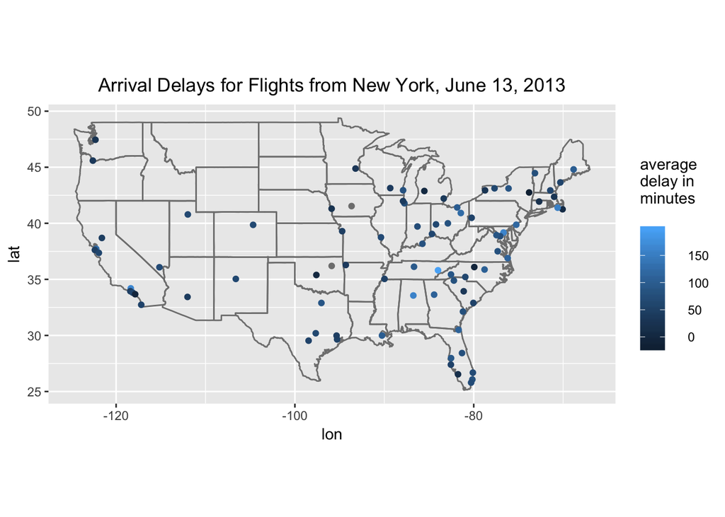

```r
ave_delay_6_13 <- flights %>%
  filter(year == 2013 & month == 6 & day ==13) %>%
  group_by(dest) %>%
  summarize(average = mean(arr_delay, na.rm = TRUE))
airport_distribution_6_13 <- ave_delay_6_13 %>% left_join(airports, by = c("dest" = "faa"))

airport_distribution_6_13 %>%
  filter(!is.na(lat) & lon > -130) %>%
  ggplot(aes(lon, lat)) +
  borders("state") +
  geom_point(aes(color = average)) +
  coord_quickmap() +
  labs(color = "average\ndelay in\nminutes",
       title = "Arrival Delays for Flights from New York, June 13, 2013") +
  theme(plot.title = element_text(hjust = .5))
```

There were notable delays in Chattanooga, Tennessee and Birmingham, Alabama. These may have been due to severe storms called decheros. See https://www.weatherworksinc.com/June-12-13-Derechoes .

### 13.5.1 Exercises

##### 1. What does it mean for a flight to have a missing tailnum? What do the tail numbers that don’t have a matching record in planes have in common? (Hint: one variable explains ~90% of the problems.)

```r
with_tailnum <- flights %>%
  left_join(planes, by = "tailnum") %>%
  count(carrier)

without_tailnum <- flights %>%
  anti_join(planes, by = "tailnum") %>%
  count(carrier)

comparison <- with_tailnum %>%
  left_join(without_tailnum, by = "carrier")

#check to see whether the `carrier` variable has `NA`s. (It doesn't)
flights %>% filter(is.na(carrier))
```

```
## # A tibble: 0 x 19
## # ... with 19 variables: year <int>, month <int>, day <int>,
## #   dep_time <int>, sched_dep_time <int>, dep_delay <dbl>, arr_time <int>,
## #   sched_arr_time <int>, arr_delay <dbl>, carrier <chr>, flight <int>,
## #   tailnum <chr>, origin <chr>, dest <chr>, air_time <dbl>,
## #   distance <dbl>, hour <dbl>, minute <dbl>, time_hour <dttm>
```

```r
comparison
```

```
## # A tibble: 16 x 3
##    carrier   n.x   n.y
##    <chr>   <int> <int>
##  1 9E      18460  1044
##  2 AA      32729 22558
##  3 AS        714    NA
##  4 B6      54635   830
##  5 DL      48110   110
##  6 EV      54173    NA
##  7 F9        685    50
##  8 FL       3260   187
##  9 HA        342    NA
## 10 MQ      26397 25397
## 11 OO         32    NA
## 12 UA      58665  1693
## 13 US      20536   699
## 14 VX       5162    NA
## 15 WN      12275    38
## 16 YV        601    NA
```

Column `n.x` reflects all of the data in the `flights` dataframe, whereas `n.y` reflects flights for which tail number information is missing. We see that MQ (Envoy Airlines) and AA (American Airlines) are responsible for most of the missing tail-number data.

##### 2. Filter `flights` to only show flights with planes that have flown at least 100 flights.

```r
at_least_hundred <- flights %>%
  filter(!is.na(arr_delay)) %>%  #avoid counting cancelled flights
  group_by(tailnum) %>%
  mutate(n = n()) %>%
  ungroup() %>%
  filter(n >= 100)

at_least_hundred
```

```
## # A tibble: 221,908 x 20
##     year month   day dep_time sched_dep_time dep_delay arr_time
##    <int> <int> <int>    <int>          <int>     <dbl>    <int>
##  1  2013     1     1      517            515      2.00      830
##  2  2013     1     1      533            529      4.00      850
##  3  2013     1     1      544            545     -1.00     1004
##  4  2013     1     1      554            558     -4.00      740
##  5  2013     1     1      555            600     -5.00      913
##  6  2013     1     1      557            600     -3.00      709
##  7  2013     1     1      557            600     -3.00      838
##  8  2013     1     1      558            600     -2.00      849
##  9  2013     1     1      558            600     -2.00      853
## 10  2013     1     1      558            600     -2.00      923
## # ... with 221,898 more rows, and 13 more variables: sched_arr_time <int>,
## #   arr_delay <dbl>, carrier <chr>, flight <int>, tailnum <chr>,
## #   origin <chr>, dest <chr>, air_time <dbl>, distance <dbl>, hour <dbl>,
## #   minute <dbl>, time_hour <dttm>, n <int>
```

The above may be the best answer if the intention is to show only the flights that were not cancelled. Otherwise, the following should work.

```r
temp <- flights %>%
  filter(!is.na(arr_delay)) %>% #to avoid counting cancelled flights has having occurred
  count(tailnum) %>%
  filter(n >= 100)

#bring back the unfiltered dataframe, so as to count all scheduled flights (whether
#cancelled or not)
second_method <- flights %>%
  semi_join(temp, by = "tailnum")

second_method
```

```
## # A tibble: 227,170 x 19
##     year month   day dep_time sched_dep_time dep_delay arr_time
##    <int> <int> <int>    <int>          <int>     <dbl>    <int>
##  1  2013     1     1      517            515      2.00      830
##  2  2013     1     1      533            529      4.00      850
##  3  2013     1     1      544            545     -1.00     1004
##  4  2013     1     1      554            558     -4.00      740
##  5  2013     1     1      555            600     -5.00      913
##  6  2013     1     1      557            600     -3.00      709
##  7  2013     1     1      557            600     -3.00      838
##  8  2013     1     1      558            600     -2.00      849
##  9  2013     1     1      558            600     -2.00      853
## 10  2013     1     1      558            600     -2.00      923
## # ... with 227,160 more rows, and 12 more variables: sched_arr_time <int>,
## #   arr_delay <dbl>, carrier <chr>, flight <int>, tailnum <chr>,
## #   origin <chr>, dest <chr>, air_time <dbl>, distance <dbl>, hour <dbl>,
## #   minute <dbl>, time_hour <dttm>
```

##### 3. Combine `fueleconomy::vehicles` and `fueleconomy::common` to find only the records for the most common models.

We can think of vehicle models at various levels specificity. When a certain car is rebranded under a different name (say, a Chevrolet branded as a GM), is it the same “model”? To see the the extent of this sort of thing (along with, probably, some other issues that could go into whether the variable `model` uniquely identifies vehicle models), consider the following calculation, which uncovers the values of `model` that have more than one corresponding vehicle make.

```r
library(fueleconomy)
vehicles %>%
  count(model, make) %>%
  group_by(model) %>%
  mutate(`number of corresponding makes` = n()) %>%
  filter(`number of corresponding makes` > 1)
```

```
## # A tibble: 126 x 4
## # Groups:   model [60]
##    model               make                       n `number of correspond…
##    <chr>               <chr>                  <int>                  <int>
##  1 200                 Audi                       4                      2
##  2 200                 Chrysler                  14                      2
##  3 240 DL/240 GL Wagon Mcevoy Motors              2                      2
##  4 240 DL/240 GL Wagon Volvo                     10                      2
##  5 300E                Lambda Control Systems     1                      2
##  6 300E                Mercedes-Benz             11                      2
##  7 300SL               J.K. Motors                2                      2
##  8 300SL               Mercedes-Benz              9                      2
##  9 500SE               Mercedes-Benz              3                      2
## 10 500SE               Texas Coach Company        1                      2
## # ... with 116 more rows
```

In most but not all of the cases, the two or three models with the different entries for `make` are significantly different. I’ll thus assume that two vehicles are different models only if the corresponding values of both `model` and `make` are different. Thus restricting the information in `vehicles` to the “common” models (those reflected in the `common` dataframe):

```r
vehicles %>%
  semi_join(common, by = c("make", "model"))
```

```
## # A tibble: 14,531 x 12
##       id make  model  year class trans drive   cyl displ fuel    hwy   cty
##    <int> <chr> <chr> <int> <chr> <chr> <chr> <int> <dbl> <chr> <int> <int>
##  1  1833 Acura Inte…  1986 Subc… Auto… Fron…     4  1.60 Regu…    28    22
##  2  1834 Acura Inte…  1986 Subc… Manu… Fron…     4  1.60 Regu…    28    23
##  3  3037 Acura Inte…  1987 Subc… Auto… Fron…     4  1.60 Regu…    28    22
##  4  3038 Acura Inte…  1987 Subc… Manu… Fron…     4  1.60 Regu…    28    23
##  5  4183 Acura Inte…  1988 Subc… Auto… Fron…     4  1.60 Regu…    27    22
##  6  4184 Acura Inte…  1988 Subc… Manu… Fron…     4  1.60 Regu…    28    23
##  7  5303 Acura Inte…  1989 Subc… Auto… Fron…     4  1.60 Regu…    27    22
##  8  5304 Acura Inte…  1989 Subc… Manu… Fron…     4  1.60 Regu…    28    23
##  9  6442 Acura Inte…  1990 Subc… Auto… Fron…     4  1.80 Regu…    24    20
## 10  6443 Acura Inte…  1990 Subc… Manu… Fron…     4  1.80 Regu…    26    21
## # ... with 14,521 more rows
```

##### 4. Find the 48 hours (over the course of the whole year) that have the worst delays. Cross-reference it with the weather data. Can you see any patterns?

This question could pertain to 48-hour periods or, instead, to sets of 48 one-hour periods. Considering the second of these readings, and supposing that the periods with the worst delays are the periods with the greatest average of all delays,

```r
average_delays <-
  flights %>%
  group_by(year, month, day, hour) %>%
  summarize(average_delay = mean(arr_delay)) %>%
  ungroup()

average_delay <- arrange(average_delays, desc(average_delay))
top_48 <- head(average_delay, n = 48L)

top_48_weather <- top_48 %>%
  left_join(weather, by = c("year", "month", "day", "hour"))

average_delays_weather <- average_delays %>%
  left_join(weather, by = c("year", "month", "day", "hour"))

ave_48 <- map_dbl(top_48_weather, mean, na.rm = TRUE)
ave_all <- map_dbl(average_delays_weather, mean, na.rm = TRUE)
difference <- ave_48 - ave_all #find the differences in the mean, where this makes sense

difference
```

```
##          year         month           day          hour average_delay
##  0.000000e+00  6.812485e-02  2.238777e+00  7.956791e+00  7.616687e+01
##        origin          temp          dewp         humid      wind_dir
##            NA  1.120726e+01  1.636398e+01  1.390006e+01 -2.581974e+01
##    wind_speed     wind_gust        precip      pressure         visib
## -4.665607e-01 -5.369088e-01  3.158352e-03 -4.334032e+00 -1.584302e+00
##     time_hour
##  3.892214e+05
```

The above shows the differences between the column means for the 48 hours with the greatest delays and the column means for all of the flights (for all of the hours of the year). As one might expect, for the 48 hours with the greatest delays, the average visibility and pressure were somewhat lesser, while the average precipitation was somewhat greater.

##### 5. What does anti_join(flights, airports, by = c(“dest” = “faa”)) tell you? What does anti_join(airports, flights, by = c(“faa” = “dest”)) tell you?

The dataframe `anti_join(flights, airports, by = c("dest" = "faa"))` identifies the flights in the `flights` dataframe for which the destination is not listed in the `airports` dataframe. Both of the flights and the airports dataframe are supposed to cover domestic flights, and airports, only. So it may seem that result of the “anti-join” include fights to domestic airports for which data in the `airports` dataframe is missing. Let’s look.

```r
anti_join(flights, airports, by = c("dest" = "faa")) %>%
  count(dest)
```

```
## # A tibble: 4 x 2
##   dest      n
##   <chr> <int>
## 1 BQN     896
## 2 PSE     365
## 3 SJU    5819
## 4 STT     522
```

All these airports are in US territories (that are not states). Rather than simply indicating missing data in the airports dataframe, the result of the anti-join may indicate an ambiguity with respect to the meaning of “domestic,” with the `airports` dataframe constructed with a somewhat more restrictive interpretation.

```r
anti_join(airports, flights, by = c("faa" = "dest")) %>%
  count(faa)
```

```
## # A tibble: 1,357 x 2
##    faa       n
##    <chr> <int>
##  1 04G       1
##  2 06A       1
##  3 06C       1
##  4 06N       1
##  5 09J       1
##  6 0A9       1
##  7 0G6       1
##  8 0G7       1
##  9 0P2       1
## 10 0S9       1
## # ... with 1,347 more rows
```

It appears that there were 1,357 domestic airports reflected in the airports data to which there were no flights (as per the `flights` data) from New York.

##### 6. You might expect that there’s an implicit relationship between plane and airline, because each plane is flown by a single airline. Confirm or reject this hypothesis using the tools you’ve learned above.

We take a quick look at the headings and initial values of some possibly relevant data frames.

```r
glimpse(airlines)
```

```
## Observations: 16
## Variables: 2
## $ carrier <chr> "9E", "AA", "AS", "B6", "DL", "EV", "F9", "FL", "HA", ...
## $ name    <chr> "Endeavor Air Inc.", "American Airlines Inc.", "Alaska...
```

```r
glimpse(planes)
```

```
## Observations: 3,322
## Variables: 9
## $ tailnum      <chr> "N10156", "N102UW", "N103US", "N104UW", "N10575",...
## $ year         <int> 2004, 1998, 1999, 1999, 2002, 1999, 1999, 1999, 1...
## $ type         <chr> "Fixed wing multi engine", "Fixed wing multi engi...
## $ manufacturer <chr> "EMBRAER", "AIRBUS INDUSTRIE", "AIRBUS INDUSTRIE"...
## $ model        <chr> "EMB-145XR", "A320-214", "A320-214", "A320-214", ...
## $ engines      <int> 2, 2, 2, 2, 2, 2, 2, 2, 2, 2, 2, 2, 2, 2, 2, 2, 2...
## $ seats        <int> 55, 182, 182, 182, 55, 182, 182, 182, 182, 182, 5...
## $ speed        <int> NA, NA, NA, NA, NA, NA, NA, NA, NA, NA, NA, NA, N...
## $ engine       <chr> "Turbo-fan", "Turbo-fan", "Turbo-fan", "Turbo-fan...
```

```r
glimpse(flights)
```

```
## Observations: 336,776
## Variables: 19
## $ year           <int> 2013, 2013, 2013, 2013, 2013, 2013, 2013, 2013,...
## $ month          <int> 1, 1, 1, 1, 1, 1, 1, 1, 1, 1, 1, 1, 1, 1, 1, 1,...
## $ day            <int> 1, 1, 1, 1, 1, 1, 1, 1, 1, 1, 1, 1, 1, 1, 1, 1,...
## $ dep_time       <int> 517, 533, 542, 544, 554, 554, 555, 557, 557, 55...
## $ sched_dep_time <int> 515, 529, 540, 545, 600, 558, 600, 600, 600, 60...
## $ dep_delay      <dbl> 2, 4, 2, -1, -6, -4, -5, -3, -3, -2, -2, -2, -2...
## $ arr_time       <int> 830, 850, 923, 1004, 812, 740, 913, 709, 838, 7...
## $ sched_arr_time <int> 819, 830, 850, 1022, 837, 728, 854, 723, 846, 7...
## $ arr_delay      <dbl> 11, 20, 33, -18, -25, 12, 19, -14, -8, 8, -2, -...
## $ carrier        <chr> "UA", "UA", "AA", "B6", "DL", "UA", "B6", "EV",...
## $ flight         <int> 1545, 1714, 1141, 725, 461, 1696, 507, 5708, 79...
## $ tailnum        <chr> "N14228", "N24211", "N619AA", "N804JB", "N668DN...
## $ origin         <chr> "EWR", "LGA", "JFK", "JFK", "LGA", "EWR", "EWR"...
## $ dest           <chr> "IAH", "IAH", "MIA", "BQN", "ATL", "ORD", "FLL"...
## $ air_time       <dbl> 227, 227, 160, 183, 116, 150, 158, 53, 140, 138...
## $ distance       <dbl> 1400, 1416, 1089, 1576, 762, 719, 1065, 229, 94...
## $ hour           <dbl> 5, 5, 5, 5, 6, 5, 6, 6, 6, 6, 6, 6, 6, 6, 6, 5,...
## $ minute         <dbl> 15, 29, 40, 45, 0, 58, 0, 0, 0, 0, 0, 0, 0, 0, ...
## $ time_hour      <dttm> 2013-01-01 05:00:00, 2013-01-01 05:00:00, 2013...
```

It looks like the `flights` dataframe may be sufficient for making this determination.

```r
fl <- flights %>%
  count(tailnum, carrier) %>%
  count(tailnum) %>%
  filter(nn > 1)
fl
```

```
## # A tibble: 18 x 2
##    tailnum    nn
##    <chr>   <int>
##  1 N146PQ      2
##  2 N153PQ      2
##  3 N176PQ      2
##  4 N181PQ      2
##  5 N197PQ      2
##  6 N200PQ      2
##  7 N228PQ      2
##  8 N232PQ      2
##  9 N933AT      2
## 10 N935AT      2
## 11 N977AT      2
## 12 N978AT      2
## 13 N979AT      2
## 14 N981AT      2
## 15 N989AT      2
## 16 N990AT      2
## 17 N994AT      2
## 18 <NA>        7
```

It would thus seem that at least 17 planes were used more by than one airline. Perhaps this reflects the fact that the same journey can be listed for more than one airline? Let’s include the airlines in this information, using `semi_join`, and see if we find, for these planes, matching flight numbers for two carriers.

```r
flj <- flights %>%
  semi_join(fl, key = "tailnum") %>%
  count(tailnum, carrier) %>%
  na.omit()
flights %>%
  semi_join(flj, by = c("tailnum", "carrier")) %>%
  count(carrier, tailnum, flight) %>%
  count(tailnum, flight) %>%
  filter(nn > 1)
```

```
## # A tibble: 0 x 3
## # ... with 3 variables: tailnum <chr>, flight <int>, nn <int>
```

Because the result here is zero rows, we see that, for the tail numbers identified in `fl`, the combination of tail number and flight is sufficient to identify the carrier. The answer to the question I posed above is thus “no.”